# Computer Vision & Natural Language Processing Applications in the Insurance Industry

Aaron Miles

11/02/2018

## About Me

**Education**

- Social Scientist turned Data Scientist
- Undergrad at BYU, Grad School at OSU

**Work**

- Past
  - Marketing Analyst/Data Scientist at Express
  - Data Scientist at The Shipyard
- Current
  - Data Scientist at Columbus Collaboratory

## Structured and Unstructured Data

- Structured Data:
  - Relational Databases
  - Spreadsheets
  - Tables, etc.
- Unstructured Data:
  - Images
  - Text
  - Video

## Structured and Unstructured Data

- Structured Data:
  - Old Reliable
  - Still Lots of Value
- Unstructured Data:
  - Wild West
  - Prime ground for innovation and value extraction
- Why?
  - Previously unanalyzed
  - Closer to what the user experiences
  - More nuanced

## Structured and Unstructured Data

**Burtch Works Classification**

- Work with unstructured data? Data Scientist
- Work only with structured data? Predictive Analytics Professional

## Why Unstructured Data Now?

Advances in:

- Storage
- Computing Efficiency
- Algorithmic Breakthroughs (Backpropogation)

## Types of Questions

- Regression: How much?
- Classification: Which group?
- Clustering: How can this be split up?
- Detection: Where is it/are they?

## Examples

Where did I find examples?

- The Internet! People love to brag about what they’re doing in this area
- Kaggle, A data science competition site
- Friends & Connections

## Computer Vision Example: Distracted Driving Detection

Using an image from a dashboard cam, can we classify what this person is doing into 10 classes:

```
- Normal Driving
- Texting (Left or Right)
- Talking on the Phone (Left or Right)
- Radio
- Hair/Makeup
- Talking to Passengers
- Reaching Behind
- Drinking
```

*Data from a competition sponsored by State Farm on Kaggle*

## Computer Vision Example: Distracted Driving Detection

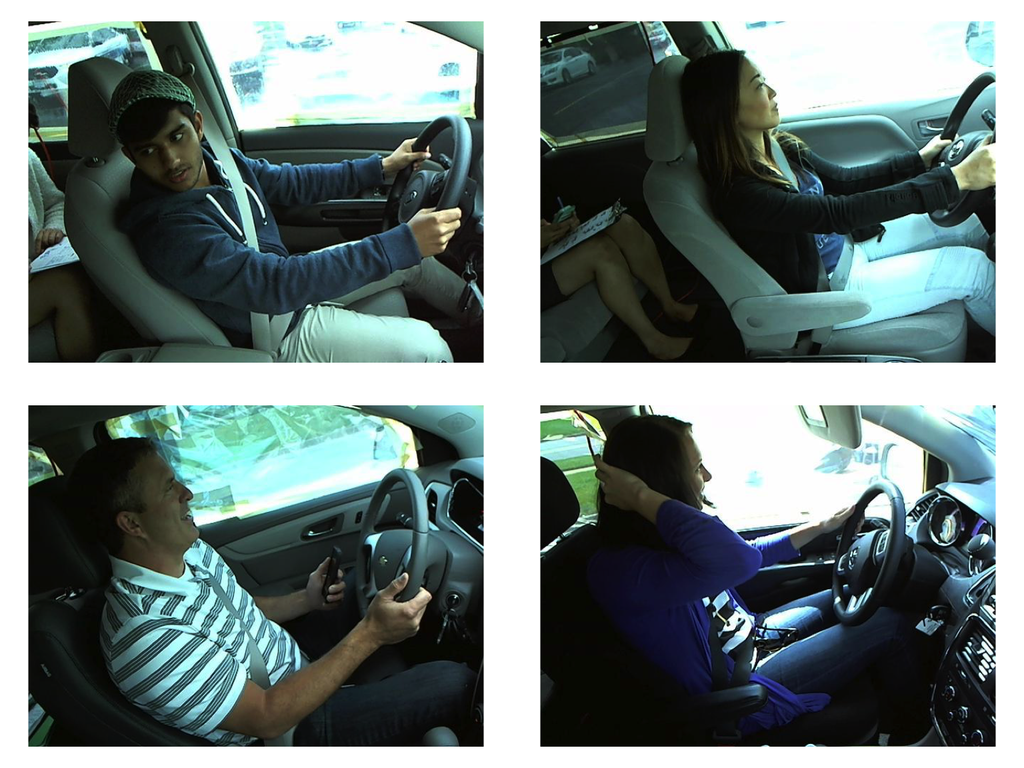

## Other Computer Vision Examples

- Snapping images of accidents to assess damage
  - Could apply to homes as well
- Drones flying over disaster areas to assess the insurer’s liability
- Estimate the CTR of a banner ad
- Webpage conversion optimization

## Natural Language Processing Example: Customer Complaint Classification

When a customer makes a complaint, how does it get to the right place?

Identifying where it should go can be done automatically.

## Natural Language Processing Example: Customer Complaint Classification

| consumercomplaintnarrative | product |
| --- | --- |
| When my loan was switched over to Navient i was never told that i had a deliquint balance because with XXXX i did not. When going to purchase a vehicle i discovered my credit score had been dropped fr… | Student loan |
| I tried to sign up for a spending monitoring program and Capital One will not let me access my account through them | Credit card or prepaid card |
| My mortgage is with BB & T Bank, recently I have been investigating ways to pay down my mortgage faster and I came across Biweekly Mortgage Calculator on BB & T ‘s website. It’s a nice, easy to use ca… | Mortgage |
| The entire lending experience with Citizens Bank was terrible. The lender kept pushing a XXXX ARM, which we had considered initially but decided to go with a 30yr fixed. When we received the closing d… | Mortgage |
| My credit score has gone down XXXX points in the last month - from the XXXX ’s to the XXXX ’s. I requested and reviewed reports from all XXXX credit reporting agencies and I can not find a significant… | Credit reporting |
| I few months back I contacted XXXX in regards to fraudulent accounts one being XXXX XXXX. I sent in the necessary documents affidavit, police report. They removed the account now the account has appea… | Credit reporting, credit repair services, or other personal consumer reports |

## Other Natural Language Processing Examples

- Augmenting Chatbots
- Analyze how the brand is talked about on Social Media/News releases.
- Added input to fraud detection or claims management systems.

## Considerations

- Too big for laptops
- LOTS of tagged data needed
- Computing power (GPU’s speed up processing, and are necessary for at least image analyses at meaningful scale)

Questions?